# Descriptive overview of LLM extractions: run 0331

Zhongtian Sun, Maxwell J. Farrell, Liam Brierley

April 20 2025

#### Check all 100 docs are present in each file:

```
## [1] 100
```

```
## [1] 100
```

```
## [1] 100
```

```
## [1] 100
```

```
## [1] 100
```

```
## [1] 100
```

```
## [1] 100
```

```
## [1] 100
```

#### Are there duplicated rows in any model outputs?

*Should be zero.*

|  | Duplicated entitity rows | Duplicated relation rows |
| --- | --- | --- |
| deepseek | 88 | 0 |
| gemma2 | 72 | 0 |
| llama | 53 | 0 |
| llama70b | 21 | 0 |
| mistral | 139 | 0 |

### Average entities/relations per doc

__

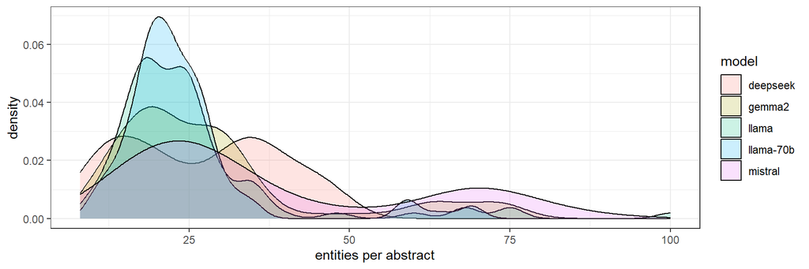

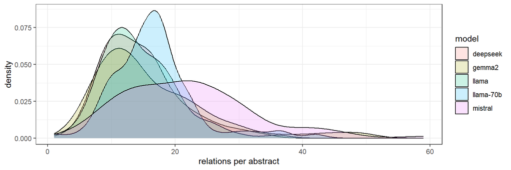

### Most common types of entities

**Note only plotted if a given threshold PER MODEL**

__

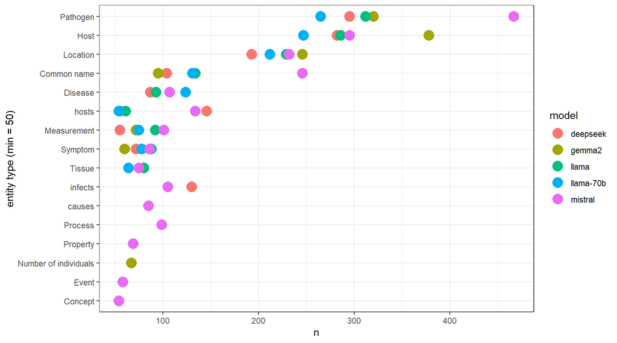

```r
ent_m %>% filter(type == "Unknown") %>% slice(1:25)
```

```
## [1] entity_id entity    type      doc_id
## <0 rows> (or 0-length row.names)
```

```r
ent_d %>% filter(type == "Undefined") %>% slice(1:25)
```

```
## [1] entity_id entity    type      doc_id
## <0 rows> (or 0-length row.names)
```

### Compare entity types for same entity texts WITHIN models

| model | 1 | 2 | 3 | 4 | 5 | 6 | 7 | 8 | 11 | 15 |
| --- | --- | --- | --- | --- | --- | --- | --- | --- | --- | --- |
| deepseek | 80.0 | 15.5 | 3.2 | 0.7 | 0.2 | 0.2 | 0.2 | NA | NA | NA |
| gemma2 | 84.9 | 12.6 | 1.6 | 0.5 | 0.1 | 0.0 | 0.0 | 0.1 | 0 | 0 |
| llama | 90.9 | 6.8 | 1.9 | 0.2 | 0.1 | NA | 0.2 | 0.1 | NA | NA |
| llama70b | 90.9 | 7.9 | 0.6 | 0.4 | 0.2 | NA | 0.1 | NA | NA | NA |
| mistral | 85.2 | 10.5 | 2.5 | 1.0 | 0.4 | 0.2 | 0.2 | 0.0 | NA | NA |

*Example entities with >1 type within model:*

```r
ent_l %>% filter(entity %in% (ent_l %>% group_by(entity) %>% summarise(nt = n_distinct(type)) %>% filter(nt>1) %>% pull(entity))) %>% arrange(desc(entity)) %>% select(-entity_id, -doc_id) %>% distinct %>% slice(1:20)
```

```
##                     entity                type
## 1  western lowland gorilla                Host
## 2  western lowland gorilla         Common name
## 3                      sex              Factor
## 4                      sex Host characteristic
## 5                      sex            Property
## 6            serum samples              Sample
## 7            serum samples              Tissue
## 8                    serum               Fluid
## 9                    serum              Tissue
## 10                   serum         Measurement
## 11               schizonts      Pathogen stage
## 12               schizonts Developmental stage
## 13                raccoons                Host
## 14                raccoons         Common name
## 15                 raccoon         Common name
## 16                 raccoon       suffered from
## 17                  rabies             Disease
## 18                  rabies            Pathogen
## 19                protozoa            Pathogen
## 20                protozoa               Group
```

### Compare entity types for same entity texts BETWEEN models

*ONLY for entities having a single type within models (i.e., 1’s in table above). Rows are n models the entity was present in, columns are n types the entity had between models. The ideal is x = 5, y = 1, i.e., the entity was extracted by all five models and all models agreed on the entity type*

|  | 1 | 2 | 3 | 4 | 5 |
| --- | --- | --- | --- | --- | --- |
| 5 | 249 | 81 | 29 | 36 | 4 |
| 4 | 249 | 130 | 80 | 23 | 0 |
| 3 | 264 | 181 | 121 | 0 | 0 |
| 2 | 402 | 348 | 0 | 0 | 0 |
| 1 | 1596 | 0 | 0 | 0 | 0 |

*Example entity with varying and non-varying types between models. Full entity-by-entity sheet is in file *model_entity_type_comparison.csv**

```r
ent_type_comp %>% filter(models_present == 5 & n_entity_types == 1) %>% sample_n(1)
```

```
## # A tibble: 1 × 8
##   entity           deepseek gemma2 llama llama70b mistral models_present n_entity_types
##   <chr>            <chr>    <chr>  <chr> <chr>    <chr>            <dbl>          <int>
## 1 Conepatus chinga Host     Host   Host  Host     Host                 5              1
```

```r
ent_type_comp %>% filter(models_present == 5 & n_entity_types == 5) %>% sample_n(1)
```

```
## # A tibble: 1 × 8
##   entity      deepseek   gemma2    llama                llama70b           mistral  models_present n_entity_types
##   <chr>       <chr>      <chr>     <chr>                <chr>              <chr>             <dbl>          <int>
## 1 bradyzoites Life stage Structure Stage of development Pathogen structure Pathogen              5              5
```

### Most common types of relations

__

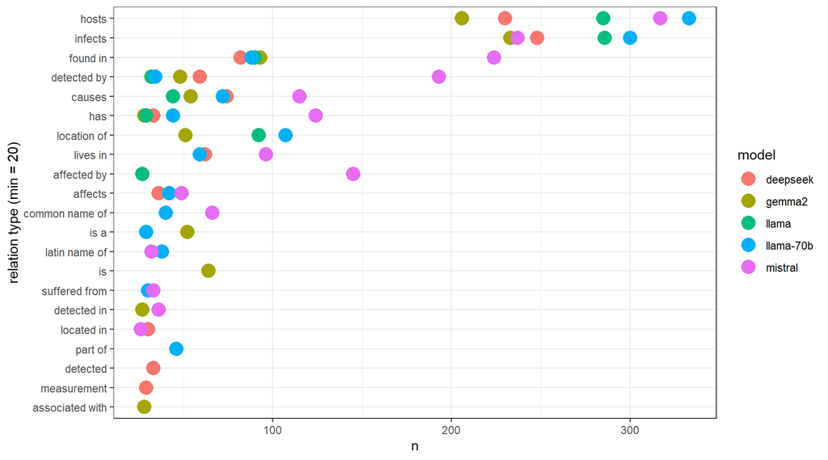

### Examine Latin name of/common name of relations

*ALL MODELS have directional errors in common/latin name of, e.g.:. This is probably then easiest to harmonise with RAG or external referencing or even embedding idea*

```r
rel_ll %>% filter(relation_type == "common name of") %>% slice(1:10)
```

```
##               source_text            target_text  relation_type doc_id
## 1              island fox     Urocyon littoralis common name of  59699
## 2     Rupicapra pyrenaica       southern chamois common name of  59578
## 3              black bear       Ursus americanus common name of  59921
## 4             Delta bison            Bison bison common name of  58455
## 5  Rocky Mountain cougars          Puma concolor common name of  59903
## 6       white-tailed deer Odocoileus virginianus common name of  59858
## 7             polar bears        Ursus maritimus common name of  57733
## 8       White-tailed deer Odocoileus virginianus common name of  59859
## 9    Amblyomma americanum         Lone star tick common name of  59859
## 10         Lone star tick   Amblyomma americanum common name of  59859
```

### Abstracts missing predefined entity and relation types:

__

|  | Abs with no ‘Host’ entity | Abs with no ‘Pathogen’ entity | Abs with no ‘hosts’ relation | Abs with no ‘infects’ relation | Abs with neither relation |
| --- | --- | --- | --- | --- | --- |
| deepseek | 1 | 2 | 11 | 10 | 8 |
| gemma2 | 0 | 6 | 24 | 22 | 21 |
| llama | 0 | 1 | 2 | 3 | 0 |
| llama70b | 0 | 1 | 1 | 3 | 1 |
| mistral | 0 | 2 | 4 | 9 | 4 |

__

__

### Find any relations whose source or target entity do not appear in the matching entities file

*Should be zero for all*

|  | Abs with ‘Source’ not in entities | Abs with ‘Target’ not in entities |
| --- | --- | --- |
| deepseek | 0 | 0 |
| gemma2 | 0 | 0 |
| llama | 0 | 0 |
| llama70b | 0 | 0 |
| mistral | 0 | 0 |